# Practical Machine Learning Project

AR

February 13, 2016

# Introduction

Devices such as Jawbone Up, Nike Fuelband and Fitbit help us collect large amount of data without much expense.One thing that people regularly do is quantify how much of a particular activity they do, but they rarely quantify how well they do it. In this project we will be using data from accelerometers on the belt, forearm,arm and dumbell of six research particpiants. Using this data, we will predict how well they did their exercise.

# Load and read the data

```r
library(caret)
```

```r
library(rpart)
library(rpart.plot)
library(randomForest)
library(corrplot)
library(knitr)
library(RColorBrewer)
library(rattle)
trainingUrl <-"https://d396qusza40orc.cloudfront.net/predmachlearn/pml-training.csv"
testingUrl <- "https://d396qusza40orc.cloudfront.net/predmachlearn/pml-testing.csv"
trainingFile <- "./data/pml-training.csv"
testingFile  <- "./data/pml-testing.csv"

if (!file.exists("./data")) {
  dir.create("./data")
}
if (!file.exists(trainingFile)) {
  download.file(trainingUrl, destfile=trainingFile, method="curl")
}
if (!file.exists(testingFile)) {
  download.file(testingUrl, destfile=testingFile, method="curl")
}
```

Having downloaded the data, we can now read the files into separate data frames.

```r
mytrain<- read.csv("./data/pml-training.csv")
mytest <- read.csv("./data/pml-testing.csv")
dim(mytrain)
```

```
## [1] 19622   160
```

```r
dim(mytest)
```

```
## [1]  20 160
```

We can see that the training set consists of 19622 observations of 160 variables. The testing set contains 20 observations of 160 variables.

# Clean the data

```r
sum(complete.cases(mytrain))
```

```
## [1] 406
```

```r
mytrain <- mytrain[, colSums(is.na(mytrain)) == 0]
mytest <- mytest[, colSums(is.na(mytest)) == 0]

classe <- mytrain$classe
trainRemove <- grepl("^X|timestamp|window", names(mytrain))
mytrain <- mytrain[, !trainRemove]
trainNew <- mytrain[, sapply(mytrain, is.numeric)]
trainNew$classe <- classe
testRemove <- grepl("^X|timestamp|window", names(mytest))
mytest <- mytest[, !testRemove]
testNew <- mytest[, sapply(mytest, is.numeric)]
```

After the cleansing, the training data set has 19622 observations of 53 variables and the testing data set has 20 observations of 53 variables.

# Split traning data

Let us split the cleaned training set into a pure training data set (60%) and a validation data set (40%). The validation dats set will be used later.

```r
set.seed(12345) # This is to ensure reproducibility
splitTrain <- createDataPartition(trainNew$classe, p=0.60, list=F)
trainData1 <- trainNew[splitTrain, ]
testData1 <- trainNew[-splitTrain, ]
```

# Predictive Modeling

## Random Forest:

Random Forest algorithm automatically selects important variables.

```r
set.seed(12345)
ctrlRF <- trainControl(method="cv", 5)
modelRF <- train(classe ~ ., data=trainData1, method="rf", trControl=ctrlRF, ntree=250)
modelRF
```

```
## Random Forest
##
## 11776 samples
##    52 predictor
##     5 classes: 'A', 'B', 'C', 'D', 'E'
##
## No pre-processing
## Resampling: Cross-Validated (5 fold)
##
## Summary of sample sizes: 9422, 9421, 9420, 9421, 9420
##
## Resampling results across tuning parameters:
##
##   mtry  Accuracy   Kappa      Accuracy SD  Kappa SD
##    2    0.9877716  0.9845293  0.002175014  0.002752255
##   27    0.9876871  0.9844227  0.004775107  0.006043185
##   52    0.9834413  0.9790503  0.006487180  0.008209079
##
## Accuracy was used to select the optimal model using  the largest value.
## The final value used for the model was mtry = 2.
```

We can now use the validation data set to validate the model.

```r
predictRF <- predict(modelRF, testData1)
conMatrixRF<-confusionMatrix(testData1$classe, predictRF)
conMatrixRF
```

```
## Confusion Matrix and Statistics
##
##           Reference
## Prediction    A    B    C    D    E
##          A 2229    3    0    0    0
##          B   11 1502    5    0    0
##          C    0   11 1356    1    0
##          D    0    0   20 1262    4
##          E    0    0    3    4 1435
##
## Overall Statistics
##
##                Accuracy : 0.9921
##                  95% CI : (0.9899, 0.9939)
##     No Information Rate : 0.2855
##     P-Value [Acc > NIR] : < 2.2e-16
##
##                   Kappa : 0.99
##  Mcnemar's Test P-Value : NA
##
## Statistics by Class:
##
##                      Class: A Class: B Class: C Class: D Class: E
## Sensitivity            0.9951   0.9908   0.9798   0.9961   0.9972
## Specificity            0.9995   0.9975   0.9981   0.9964   0.9989
## Pos Pred Value         0.9987   0.9895   0.9912   0.9813   0.9951
## Neg Pred Value         0.9980   0.9978   0.9957   0.9992   0.9994
## Prevalence             0.2855   0.1932   0.1764   0.1615   0.1834
## Detection Rate         0.2841   0.1914   0.1728   0.1608   0.1829
## Detection Prevalence   0.2845   0.1935   0.1744   0.1639   0.1838
## Balanced Accuracy      0.9973   0.9941   0.9890   0.9962   0.9981
```

```r
accuracy <- postResample(predictRF, testData1$classe)
accuracy
```

```
##  Accuracy     Kappa
## 0.9920979 0.9900033
```

```r
outofsample <- 1 - as.numeric(confusionMatrix(testData1$classe, predictRF)$overall[1])
outofsample
```

```
## [1] 0.007902116
```

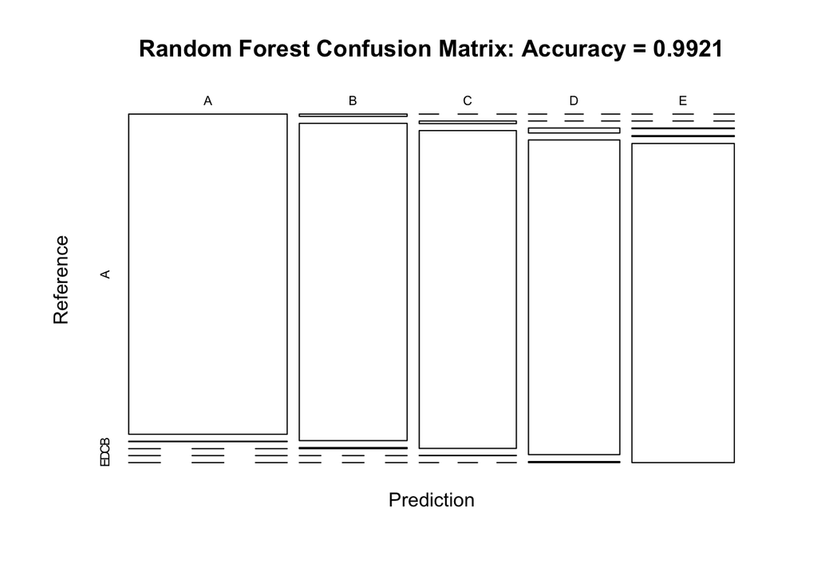

```r
plot(conMatrixRF$table, col = conMatrixRF$byClass, main = paste("Random Forest Confusion Matrix: Accuracy =", round(conMatrixRF$overall['Accuracy'], 4)))
```

The Accuracy is 99.21 % and the Out of Sample error is 0.79%.

## Decision Tree:

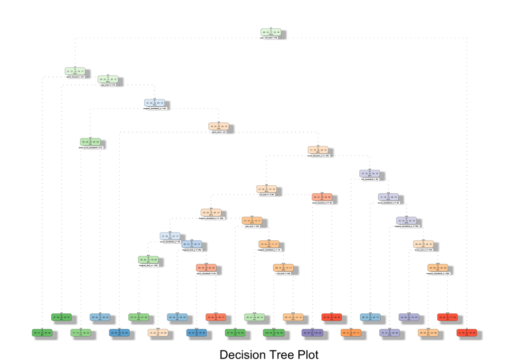

```r
set.seed(12345)
modelDT <- rpart(classe ~ ., data=trainData1, method="class")
fancyRpartPlot(modelDT, main='',sub='Decision Tree Plot' )
```

```r
predictDT <- predict(modelDT, testData1, type = "class")
conMatrixDT<-confusionMatrix(predictDT, testData1$classe)
conMatrixDT
```

```
## Confusion Matrix and Statistics
##
##           Reference
## Prediction    A    B    C    D    E
##          A 1879  260   30   69   66
##          B   56  759   88   34   54
##          C  105  340 1226  354  234
##          D  155  132   23  807   57
##          E   37   27    1   22 1031
##
## Overall Statistics
##
##                Accuracy : 0.7267
##                  95% CI : (0.7167, 0.7366)
##     No Information Rate : 0.2845
##     P-Value [Acc > NIR] : < 2.2e-16
##
##                   Kappa : 0.6546
##  Mcnemar's Test P-Value : < 2.2e-16
##
## Statistics by Class:
##
##                      Class: A Class: B Class: C Class: D Class: E
## Sensitivity            0.8418  0.50000   0.8962   0.6275   0.7150
## Specificity            0.9243  0.96334   0.8405   0.9441   0.9864
## Pos Pred Value         0.8155  0.76589   0.5427   0.6874   0.9222
## Neg Pred Value         0.9363  0.88928   0.9746   0.9282   0.9389
## Prevalence             0.2845  0.19347   0.1744   0.1639   0.1838
## Detection Rate         0.2395  0.09674   0.1563   0.1029   0.1314
## Detection Prevalence   0.2937  0.12631   0.2879   0.1496   0.1425
## Balanced Accuracy      0.8831  0.73167   0.8684   0.7858   0.8507
```

```r
accuracy <- postResample(predictDT, testData1$classe)
accuracy
```

```
##  Accuracy     Kappa
## 0.7267397 0.6545871
```

```r
outofsample <- 1 - as.numeric(confusionMatrix(testData1$classe, predictDT)$overall[1])
outofsample
```

```
## [1] 0.2732603
```

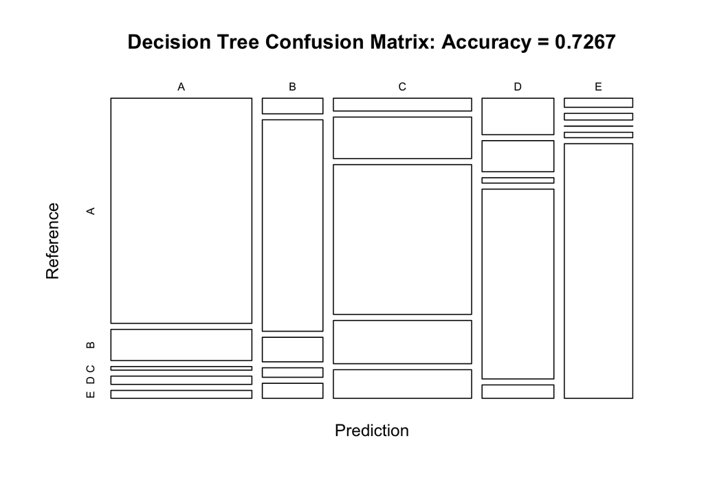

```r
plot(conMatrixDT$table, col = conMatrixDT$byClass, main = paste("Decision Tree Confusion Matrix: Accuracy =", round(conMatrixDT$overall['Accuracy'], 4)))
```

The Accuracy is 72.68 % and the Out of Sample error is 27.32 %

# Results

Between the two models, the Random Forest model with an accuracy of 99.21% is better than the Decision Tree model that had an accuracy of 72.68%. We will use the Random Forst model to run predictions on the original test data set. The results are below.

```r
result <- predict(modelRF, testNew[, -length(names(testNew))])
result
```

```
##  [1] B A B A A E D B A A B C B A E E A B B B
## Levels: A B C D E
```